# R Notebook

#### Librerías necesarias

```r
# install the package
# install.packages("ggstatsplot")
# Load the package
```

```r
library(ggplot2)
library(gridExtra)
library(MASS)
library(fitdistrplus)
library(ggstatsplot)
```

#### Funciones utilizadas

```r
fitData <- function(data, fit="gamma", sample=sample){
 distrib = list()
 numfit <- length(fit)
 results = matrix(0, ncol=5, nrow=numfit)

 for(i in 1:numfit){
if((fit[i] == "gamma") |
     (fit[i] == "poisson") |
     (fit[i] == "weibull") |
     (fit[i] == "exponential") |
     (fit[i] == "logistic") |
     (fit[i] == "normal") |
     (fit[i] == "geometric")
)
  distrib[[i]] = fit[i]
else stop("Provide a valid distribution to fit data" )
 }

 # take a sample of dataset
 n = round(length(data)*sample)
 data = sample(data, size=n, replace=F)

 for(i in 1:numfit) {
  if(distrib[[i]] == "gamma") {
  gf_shape = "gamma"
  fd_g <- fitdistr(data, "gamma")
  est_shape = fd_g$estimate[[1]]
  est_rate = fd_g$estimate[[2]]

  ks = ks.test(data, "pgamma", shape=est_shape, rate=est_rate)

  # add to results
  results[i,] = c(gf_shape, est_shape, est_rate, ks$statistic, ks$p.value)
}

else if(distrib[[i]] == "poisson"){
  gf_shape = "poisson"
  fd_p <- fitdistr(data, "poisson")
  est_lambda = fd_p$estimate[[1]]

  ks = ks.test(data, "ppois", lambda=est_lambda)
  # add to results
  results[i,] = c(gf_shape, est_lambda, "NA", ks$statistic, ks$p.value)
}

else if(distrib[[i]] == "weibull"){
  gf_shape = "weibull"
  fd_w <- fitdistr(data,densfun=dweibull,start=list(scale=1,shape=2))
  est_shape = fd_w$estimate[[1]]
  est_scale = fd_w$estimate[[2]]

  ks = ks.test(data, "pweibull", shape=est_shape, scale=est_scale)
  # add to results
  results[i,] = c(gf_shape, est_shape, est_scale, ks$statistic, ks$p.value)
}

else if(distrib[[i]] == "normal"){
  gf_shape = "normal"
  fd_n <- fitdistr(data, "normal")
  est_mean = fd_n$estimate[[1]]
  est_sd = fd_n$estimate[[2]]

  ks = ks.test(data, "pnorm", mean=est_mean, sd=est_sd)
  # add to results
  results[i,] = c(gf_shape, est_mean, est_sd, ks$statistic, ks$p.value)
}

else if(distrib[[i]] == "exponential"){
  gf_shape = "exponential"
  fd_e <- fitdistr(data, "exponential")
  est_rate = fd_e$estimate[[1]]
  ks = ks.test(data, "pexp", rate=est_rate)
  # add to results
  results[i,] = c(gf_shape, est_rate, "NA", ks$statistic, ks$p.value)
}

else if(distrib[[i]] == "logistic"){
  gf_shape = "logistic"
  fd_l <- fitdistr(data, "logistic")
  est_location = fd_l$estimate[[1]]
  est_scale = fd_l$estimate[[2]]
  ks = ks.test(data, "plogis", location=est_location, scale=est_scale)
  # add to results
  results[i,] = c(gf_shape, est_location, est_scale, ks$statistic,    ks$p.value)
    }
  }
  results = rbind(c("distribution", "param1", "param2", "ks stat", "ks    pvalue"),   results)
  #print(results)
  return(results)
  }
```

### Obtener datos en dataframe y lista

```r
### Ubicacion de datos
rm(list=ls())
setwd("C:/hcgalvan/Repositorios/hcgalvan_project/data/union/End")
ls()
```

```
character(0)
```

```r
### obtener en dataframe y lista
temp = gsub(".*target.*", "", readLines("seleccionestudio.csv"))
data<-read.table(text=temp, sep=",", header=TRUE)
names(data)
```

```
 [1] "sl2l_diameter"    "ccbd_diameter"    "ifol_diameter"    "ecpl_volume"      "tral_volume"
 [6] "sl2l_mean_length" "ccbd_mean_length" "age"              "gender_F"         "gender_M"
[11] "label"
```

```r
sl2l_dm <- as.numeric(unlist(data['sl2l_diameter']))
datos<-data.frame("sl2l_dm"= sl2l_dm)
dim(data)
```

```
[1] 96 11
```

Separamos los datos de la variable de estudio

```r
Control<-(as.numeric(unlist(subset(data, label==1, select=c(sl2l_diameter)))))
Estudio<-(as.numeric(unlist(subset(data, label==0, select=c(sl2l_diameter)))))
```

Ajustamos los outliers en base a Primer barrido.

```r
Q <- quantile(data$sl2l_diameter, probs=c(.25, .75), na.rm = FALSE)
iqr <- IQR(data$sl2l_diameter)
up <-  Q[2]+1.5*iqr # Upper Range
low<- Q[1]-1.5*iqr # Lower Range
datasinout<- subset(data, data$sl2l_diameter > (Q[1] - 1.5*iqr) & data$sl2l_diameter < (Q[2]+1.5*iqr))
```

Ajustamos los outliers en base a Segundor barrido.

```r
Q1 <- quantile(datasinout$sl2l_diameter, probs=c(.25, .75), na.rm = FALSE)
iqr1 <- IQR(datasinout$sl2l_diameter)
up1 <-  Q1[2]+1.5*iqr1 # Upper Range
low1<- Q1[1]-1.5*iqr1 # Lower Range
datasinout1<- subset(datasinout, datasinout$sl2l_diameter > (Q1[1] - 1.5*iqr1) & datasinout$sl2l_diameter < (Q1[2]+1.5*iqr1))
```

Graficamos la evolución y separamos los datos en 2 grupos: Estudio y Control

```
[1] 15.1676 15.3875 16.1625 15.1676 15.3875 16.1625 15.5295 29.4518
```

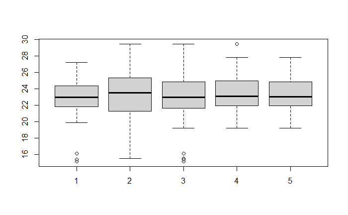

```r
boxplot(Control, Estudio, datos$sl2l_dm, datasinout$sl2l_diameter, datasinout1$sl2l_diameter)$out
```

Graficamos las distribuciones obtenidos: Ajustade total, ajuste parcial, sin ajuste

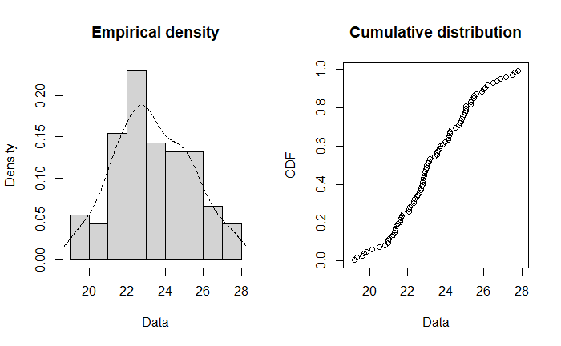

```r
plotdist(datasinout1$sl2l_diameter, histo=TRUE, demp=TRUE)
```

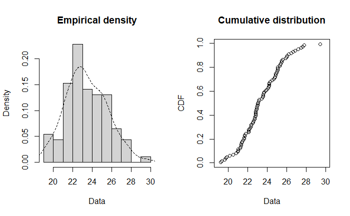

```r
plotdist(datasinout$sl2l_diameter, histo=TRUE, demp=TRUE)
```

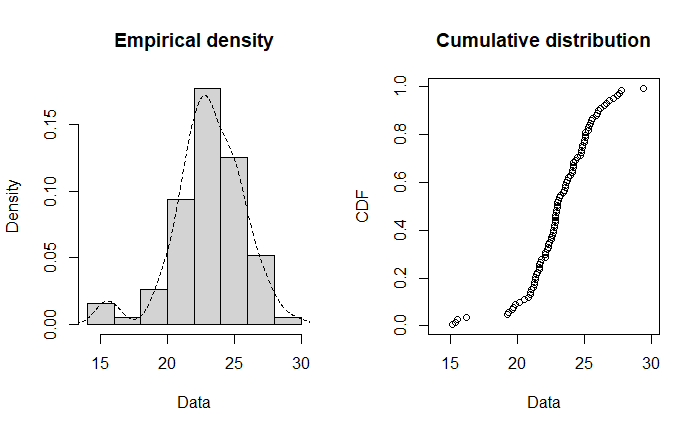

```r
plotdist(data$sl2l_diameter, histo=TRUE, demp=TRUE)
```

Realizamos descripcion de los valores descriptivos: Ajuste total, parcial y sin ajuste

```r
summary(datasinout1$sl2l_diameter)
```

```
   Min. 1st Qu.  Median    Mean 3rd Qu.    Max.
  19.22   21.94   23.03   23.35   24.87   27.80
```

```r
summary(datasinout$sl2l_diameter)
```

```
   Min. 1st Qu.  Median    Mean 3rd Qu.    Max.
  19.22   22.01   23.06   23.42   24.91   29.45
```

```r
summary(data$sl2l_diameter)
```

```
   Min. 1st Qu.  Median    Mean 3rd Qu.    Max.
  15.17   21.66   22.99   23.09   24.86   29.45
```

Graficamos la densidad de distribución: Ajuste Total, Parcial y sin ajustes

```
summary statistics
------
min:  19.2194   max:  27.8029
median:  23.0274
mean:  23.35374
estimated sd:  2.001336
estimated skewness:  0.144841
estimated kurtosis:  2.525903
```

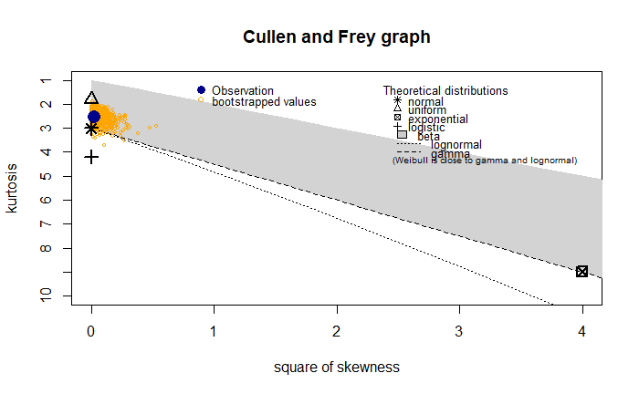

```r
descdist(datasinout1$sl2l_diameter, boot = 1000)
```

```
summary statistics
------
min:  19.2194   max:  29.4518
median:  23.06015
mean:  23.42003
estimated sd:  2.089385
estimated skewness:  0.3078107
estimated kurtosis:  2.889727
```

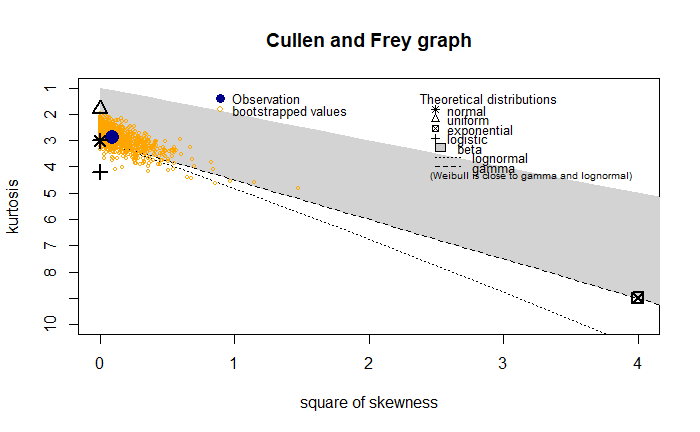

```r
descdist(datasinout$sl2l_diameter, boot = 1000)
```

```
summary statistics
------
min:  15.1676   max:  29.4518
median:  22.9899
mean:  23.0926
estimated sd:  2.584422
estimated skewness:  -0.6708646
estimated kurtosis:  4.549604
```

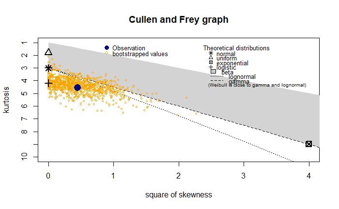

```r
descdist(data$sl2l_diameter, boot = 1000)
```

Ajustamos los datos a la distribución normal y obtenemos

```r
library(glogis)
total<-fitdist(datasinout1$sl2l_diameter, "norm")
parcial<-fitdist(datasinout$sl2l_diameter, "norm")
sinajuste<-fitdist(data$sl2l_diameter, "norm")
fw<-fitdist(sl2l_dm, "logis")
summary(total)
```

```
Fitting of the distribution ' norm ' by maximum likelihood
Parameters :
```

|  | estimate | Std. Error |
| --- | --- | --- |
| mean | 23.353744 | 0.2086411 |
| sd | 1.990309 | 0.1475314 |

```
Loglikelihood:  -191.7578   AIC:  387.5156   BIC:  392.5373
Correlation matrix:
     mean sd
mean    1  0
sd      0  1
```

```r
summary(parcial)
```

```
Fitting of the distribution ' norm ' by maximum likelihood
Parameters :
```

|  | estimate | Std. Error |
| --- | --- | --- |
| mean | 23.420027 | 0.2166463 |
| sd | 2.077999 | 0.1531919 |

```
Loglikelihood:  -197.8316   AIC:  399.6632   BIC:  404.7068
Correlation matrix:
     mean sd
mean    1  0
sd      0  1
```

```r
summary(sinajuste)
```

```
Fitting of the distribution ' norm ' by maximum likelihood
Parameters :
```

|  | estimate | Std. Error |
| --- | --- | --- |
| mean | 23.092600 | 0.2623940 |
| sd | 2.570926 | 0.1855405 |

```
Loglikelihood:  -226.8676   AIC:  457.7353   BIC:  462.864
Correlation matrix:
     mean sd
mean    1  0
sd      0  1
```

```r
summary(fw)
```

```
Fitting of the distribution ' logis ' by maximum likelihood
Parameters :
```

|  | estimate | Std. Error |
| --- | --- | --- |
| location | 23.193508 | 0.2432675 |
| scale | 1.384082 | 0.1186490 |

```
Loglikelihood:  -224.0772   AIC:  452.1545   BIC:  457.2832
Correlation matrix:
             location        scale
location  1.000000000 -0.005737615
scale    -0.005737615  1.000000000
```

```r
par(mfrow = c(2, 2), mar = c(4, 4, 2, 1))
plot.legend <- c("Ajuste Total ~N", "Ajuste Parc ~N","Sin Ajuste ~N","Sin Ajuste ~Logis" )
denscomp(total, legendtext = plot.legend[1])
denscomp(parcial, legendtext = plot.legend[2])
```

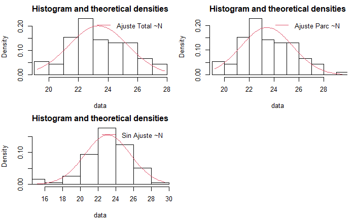

```r
denscomp(sinajuste, legendtext = plot.legend[3])
denscomp(fw, legendtext = plot.legend[4])
```

```r
par(mfrow = c(2, 2), mar = c(4, 4, 2, 1))
plot.legend <- c("Ajuste Total ~N", "Ajuste Parc ~N","Sin Ajuste ~N","Sin Ajuste ~Logis" )
qqcomp(total, legendtext = plot.legend[1])
qqcomp(parcial, legendtext = plot.legend[2])
```

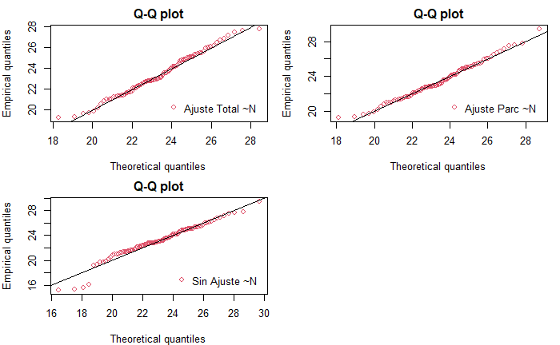

```r
qqcomp(sinajuste, legendtext = plot.legend[3])
qqcomp(fw, legendtext = plot.legend[4])
```

```r
par(mfrow = c(2, 2), mar = c(4, 4, 2, 1))
plot.legend <- c("Ajuste Total ~N", "Ajuste Parc ~N","Sin Ajuste ~N","Sin Ajuste ~Logis" )
cdfcomp(total, legendtext = plot.legend[1])
cdfcomp(parcial, legendtext = plot.legend[2])
```

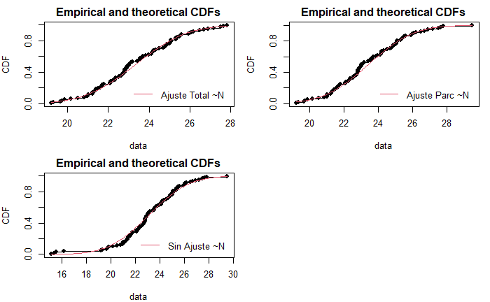

```r
cdfcomp(sinajuste, legendtext = plot.legend[3])
cdfcomp(fw, legendtext = plot.legend[4])
```

```r
par(mfrow = c(2, 2), mar = c(4, 4, 2, 1))
plot.legend <- c("Ajuste Total ~N", "Ajuste Parc ~N","Sin Ajuste ~N","Sin Ajuste ~Logis" )
ppcomp(total, legendtext = plot.legend[1])
ppcomp(parcial, legendtext = plot.legend[2])
```

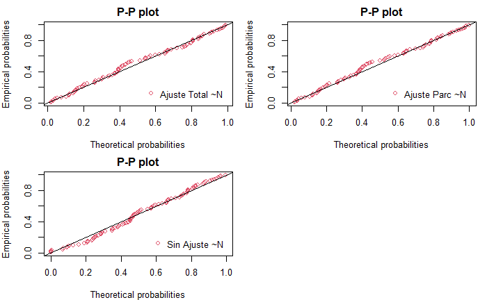

```r
ppcomp(sinajuste, legendtext = plot.legend[3])
ppcomp(fw, legendtext = plot.legend[4])
```

```r
par(mfrow = c(2, 2), mar = c(4, 4, 2, 1))
fg <- fitdist(sl2l_dm, "logis")
fln <- fitdist(sl2l_dm, "norm")
plot.legend <- c("logistic", "norm")
denscomp(list(fw, fln, fg), legendtext = plot.legend)
qqcomp(list(fw, fln, fg), legendtext = plot.legend)
```

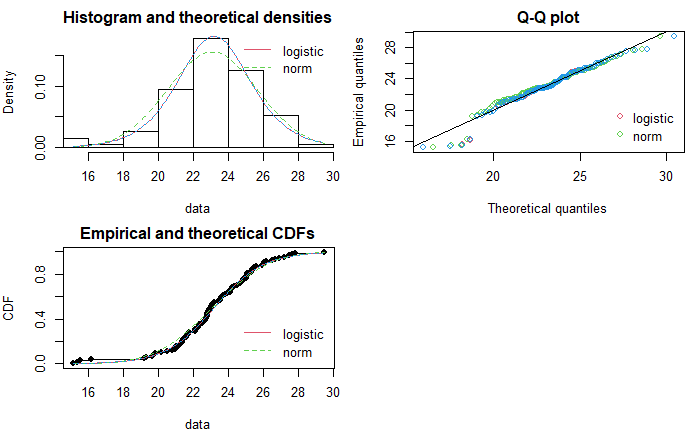

```r
cdfcomp(list(fw, fln, fg), legendtext = plot.legend)
ppcomp(list(fw, fln, fg), legendtext = plot.legend)
```